# FinalProject1

Matthew Bielskas

November 5, 2018

## Setup

```r
#Set up libraries and view data
library(tidyverse)
library(caret)
library(e1071)
library(randomForest)
library(ipred)
library(gmodels)
library(adabag)
```

```r
library(ada)
library(mlbench)
library(ggcorrplot)
library(C50)
library(stringr)
library(cvTools)
flowData <- read.csv("C:/Users/mb6xn/DS4001/capture20110810.binetflow") #1 (from CTU-13 site)
#Out of necessity, get rid of sTos and dTos because too many botnet flows are missing one of them.
flowData <- select(flowData, -sTos, -dTos)
flow1 <- read.csv("C:/Users/mb6xn/DS4001/capture20110812.binetflow")   #3
flow1 <- select(flow1, -sTos, -dTos)
flow2 <- read.csv("C:/Users/mb6xn/DS4001/capture20110816.binetflow")   #6
flow2 <- select(flow2, -sTos, -dTos)
flow3 <- read.csv("C:/Users/mb6xn/DS4001/capture20110816-3.binetflow") #8
flow3 <- select(flow3, -sTos, -dTos)
flow4 <- read.csv("C:/Users/mb6xn/DS4001/capture20110818.binetflow")   #10
flow4 <- select(flow4, -sTos, -dTos)
```

I wanted to use five different datasets when constructing my models. So my first step is to read each of these from “binetflow” files. Then I immediately eliminate the features sTos and dTos. sTos originally caused me problems because so many bot flows had an NA value for it. dTos is also mostly zero and thus not helpful.

NOTE: I originally only wanted to work with one particular dataset, so until noted I am only working off of flowData.

## Initial Exploration

```r
#Filter to see Botnet flows
bots <- filter(flowData, grepl("Botnet",Label))
bots$sTos=NULL
bots$dTos=NULL
botsInfo <- bots %>% filter(grepl("DNS",bots$Label)) %>% summarize(dns=n())
botsInfo2 <- bots %>% summarize(total=n(), dProp=botsInfo$dns/total)
#flows with DNS include "UDP-DNS" and "UDP-Attempt-DNS"
mutate(botsInfo, total=botsInfo2$total, dProp=botsInfo2$dProp)
```

```
##     dns total  dProp
## 1 29197 40961 0.7128
```

```r
#Note that ~71% of packets sent from the Botnet are either successful or attempted DNS queries

#As we can see, 12835 of the 40961 observations have an NA value for dTos.
```

This is an early initial exploration of the data. When beginning the project, I was eager to combine a standard analysis of the CTU-13 data with text analysis of DNS queries. However the binetflow files did not have any readable DNS lookup names. Here I isolated the bot flows from flowData, and then I discovered that about 71% of them were involved in DNS via their Label. Note that I repeatedly use grepl for parsing text.

# Simplify Dataset and add Binary Classifier

```
##       Dur               Proto            Sport            Dir
##  Min.   :   0.000   udp    :199960   Min.   :    1   right  : 57239
##  1st Qu.:   0.000   tcp    : 47048   1st Qu.:13363   quRight:   345
##  Median :   0.002   icmp   :  2562   Median :39498   left   :     4
##  Mean   : 396.770   rtp    :   232   Mean   :34356   both   :191918
##  3rd Qu.:   8.999   rtcp   :   198   3rd Qu.:52811   quLeft :     0
##  Max.   :3600.000   arp    :     0   Max.   :65535   quBoth :   494
##                     (Other):     0                   idk    :     0
##      Dport             State           TotPkts            TotBytes
##  Min.   :    1   CON      :191799   Min.   :     1.0   Min.   :6.000e+01
##  1st Qu.:   53   FSPAaFSPA: 17953   1st Qu.:     2.0   1st Qu.:2.080e+02
##  Median :  443   Sa       : 10593   Median :     2.0   Median :2.520e+02
##  Mean   : 8848   INT      :  8523   Mean   :    22.6   Mean   :1.737e+04
##  3rd Qu.:13363   SaRA     :  5092   3rd Qu.:     4.0   3rd Qu.:5.650e+02
##  Max.   :65535   SRPAaFSPA:  2875   Max.   :977749.0   Max.   :1.234e+09
##                  (Other)  : 13165
##     SrcBytes           bin
##  Min.   :       0   FALSE:225000
##  1st Qu.:      77   TRUE : 25000
##  Median :      81
##  Mean   :    1602
##  3rd Qu.:     228
##  Max.   :75381897
##
```

So flowData alone has more than 2,000,000 observations. Before critically thinking about this, I tried a C5.0 model and was concerned that I needed an extremely large amount of RAM. Also an overwhelming majority of the flows were not bot-related. To solve this dilemma, I decided I should find shrink down to a 250,000-observation dataframe and bring the ratio slightly down to 90/10. At the time I thought this was a nice balance between striving for good data analysis, and not making things impossible to run on a typical laptop. Before trying C5.0 for the first time, I realized that StartTime was not a useful feature because it is unique for every flow. I also decided to replace the more complicated label with “bin”, an indicator variable that is TRUE if a flow corresponds to a botnet and FALSE otherwise. SrcAddr and DstAddr will be discussed shortly.

# C5.0 Original Features

After originally testing the C5.0 algorithm (not shown), I was concerned because I achieved 100% accuracy. By checking the Bot dataframe, I realized that the bots report to a fixed botmaster which clearly caused bias in my results. Thus it is a necessary step to remove the Source and Destination IP features.

```r
set.seed(345) #Seed set to save randomness
index <- createDataPartition(flowData1$bin, p=0.8, list=FALSE) #80/20 training and test set
flow_train <- flowData1[index,]  #Recall that flowData1 has been randomly mixed.
flow_test <- flowData1[-index,]

flowC50 <- C5.0(bin~., data=flow_train)  #model

flow_pred <- predict(flowC50, flow_test)  #makes prediction

CrossTable(flow_test$bin, flow_pred,   #visualize results in a CrossTable.
           prop.chisq = FALSE, prop.c = FALSE, prop.r = FALSE,
           dnn = c('actual Class', 'predicted Class'))
```

```
##
##
##    Cell Contents
## |-------------------------|
## |                       N |
## |         N / Table Total |
## |-------------------------|
##
##
## Total Observations in Table:  50000
##
##
##              | predicted Class
## actual Class |     FALSE |      TRUE | Row Total |
## -------------|-----------|-----------|-----------|
##        FALSE |     44966 |        34 |     45000 |
##              |     0.899 |     0.001 |           |
## -------------|-----------|-----------|-----------|
##         TRUE |        28 |      4972 |      5000 |
##              |     0.001 |     0.099 |           |
## -------------|-----------|-----------|-----------|
## Column Total |     44994 |      5006 |     50000 |
## -------------|-----------|-----------|-----------|
##
##
```

So here I get very impressive results, just from a C5.0 tree with no additional featres. However note that the CRT-13 botnet datasets vary in the activities that the botnet partakes in. To accompany for this diversity, let’s divide the training and test set into assorted CRT-13 datasets. For the sake of computational power, I will work with a concatenation of these datasets reduced down to a 1000/9000-observation split each.

But before that, I wanted to experiment with engineered features.

# New Features

```r
#DNS -> Port 53, likely to be involved in a botnet.
flowData2 <- flowData1

flowData2 <- flowData1 %>% mutate(DNS=as.factor(Dport==53), highPort=as.factor(Dport>9999), bytePerPacket=TotPkts/TotBytes, byteRate=TotBytes/Dur, packetRate=bytePerPacket*byteRate, fragmented=as.factor(TotBytes>65535))
#Inf -> dur=0      let's add a feature for Dur=0
flowData2 <- flowData2 %>% mutate(emptyDur=as.factor(as.numeric(Dur)==0), S=as.factor(grepl("Sa", State)))

#Replace Inf with 99999999
flowData2[flowData2 == Inf] <- 999999999
summary(flowData2)
```

```
##       Dur               Proto            Sport            Dir
##  Min.   :   0.000   udp    :199960   Min.   :    1   right  : 57239
##  1st Qu.:   0.000   tcp    : 47048   1st Qu.:13363   quRight:   345
##  Median :   0.002   icmp   :  2562   Median :39498   left   :     4
##  Mean   : 396.770   rtp    :   232   Mean   :34356   both   :191918
##  3rd Qu.:   8.999   rtcp   :   198   3rd Qu.:52811   quLeft :     0
##  Max.   :3600.000   arp    :     0   Max.   :65535   quBoth :   494
##                     (Other):     0                   idk    :     0
##      Dport             State           TotPkts            TotBytes
##  Min.   :    1   CON      :191799   Min.   :     1.0   Min.   :6.000e+01
##  1st Qu.:   53   FSPAaFSPA: 17953   1st Qu.:     2.0   1st Qu.:2.080e+02
##  Median :  443   Sa       : 10593   Median :     2.0   Median :2.520e+02
##  Mean   : 8848   INT      :  8523   Mean   :    22.6   Mean   :1.737e+04
##  3rd Qu.:13363   SaRA     :  5092   3rd Qu.:     4.0   3rd Qu.:5.650e+02
##  Max.   :65535   SRPAaFSPA:  2875   Max.   :977749.0   Max.   :1.234e+09
##                  (Other)  : 13165
##     SrcBytes           bin            DNS          highPort
##  Min.   :       0   FALSE:225000   FALSE:153874   FALSE:139731
##  1st Qu.:      77   TRUE : 25000   TRUE : 96126   TRUE :110269
##  Median :      81
##  Mean   :    1602
##  3rd Qu.:     228
##  Max.   :75381897
##
##  bytePerPacket          byteRate           packetRate
##  Min.   :0.0006632   Min.   :        0   Min.   :        0
##  1st Qu.:0.0061919   1st Qu.:      103   1st Qu.:        1
##  Median :0.0093458   Median :   136319   Median :     1198
##  Mean   :0.0095086   Mean   : 31036698   Mean   : 30682980
##  3rd Qu.:0.0143885   3rd Qu.:   723404   3rd Qu.:     6006
##  Max.   :0.0166667   Max.   :999999999   Max.   :999999999
##
##  fragmented      emptyDur          S
##  FALSE:247851   FALSE:242330   FALSE:233729
##  TRUE :  2149   TRUE :  7670   TRUE : 16271
##
##
##
##
##
```

I was interested in DNS from the “Initial Exploration”, so of course I had to make it a feature. DNS is uniquely identified by port 53. Also I know that high ports ( >10,000) are rarely used, so they could help indicate bot flows. Then I thought I should mess around with division. To me the obvious features were bytes-per-packet, bytes-per-duration, and packets-per-duration. From this division I got “inf” which meant infinity. This led me to discover that some Durations are in fact zero. I decided to fix this by turning them into large integers, and then creating a feature to indicate if dur=0.

As a state, RST means that the host refuses to make a connection. I wanted to find these RST states among the flow dataframe, but unfortunately I couldn’t. The next best thing I could do was make an indicator variable S for observations I could parse an “S_”" from (which I turned into “Sa” due to the special character). This came from intuition after seeing that the most common state names after CON tended to have an “S_”" somewhere.

# Try C5.0 again

```r
set.seed(345)
index <- createDataPartition(flowData2$bin, p=0.8, list=FALSE)
flow_train <- flowData2[index,]
flow_test <- flowData2[-index,]
flowC50 <- C5.0(bin~., data=flow_train)
flow_pred <- predict(flowC50, flow_test)

CrossTable(flow_test$bin, flow_pred,
           prop.chisq = FALSE, prop.c = FALSE, prop.r = FALSE,
           dnn = c('actual Class', 'predicted Class'))
```

```
##
##
##    Cell Contents
## |-------------------------|
## |                       N |
## |         N / Table Total |
## |-------------------------|
##
##
## Total Observations in Table:  50000
##
##
##              | predicted Class
## actual Class |     FALSE |      TRUE | Row Total |
## -------------|-----------|-----------|-----------|
##        FALSE |     44963 |        37 |     45000 |
##              |     0.899 |     0.001 |           |
## -------------|-----------|-----------|-----------|
##         TRUE |        27 |      4973 |      5000 |
##              |     0.001 |     0.099 |           |
## -------------|-----------|-----------|-----------|
## Column Total |     44990 |      5010 |     50000 |
## -------------|-----------|-----------|-----------|
##
##
```

```r
varImp(flowC50)
```

```
##               Overall
## Sport          100.00
## Dport           17.75
## State            8.46
## SrcBytes         3.40
## packetRate       2.65
## TotBytes         2.38
## Dur              2.25
## Proto            1.80
## bytePerPacket    1.31
## TotPkts          0.58
## byteRate         0.25
## highPort         0.09
## Dir              0.01
## DNS              0.00
## fragmented       0.00
## emptyDur         0.00
## S                0.00
```

Here we show variable importance, which reveals that SPort and DPort are by far the most important features including even the new ones. In fact, the confusion matrix is pretty much the same as before. The multi-dataset approach will prove to provide more exciting results.

# NOTE: Now all 5 datasets are used.

# Let’s repeat this process with a cross-validation approach (over these sections)

# Create dataframe for CV approach

```r
#1
noBots1 <- filter(na.omit(flowData), !grepl("Botnet",Label)) #randomly sample 9000 non-bot flows from #1
noPart1 <- sample_n(noBots1, 9000)
bot1 <- filter(na.omit(flowData), grepl("Botnet",Label)) #randomly sample 1000 bot flows
botPart1 <- sample_n(bot1,1000)
flowF1 <- rbind(noPart1, botPart1) #bind non-bot and bot flows, randomize again
flowF1 <- sample_n(flowF1, 10000)
#2
noBots2 <- filter(na.omit(flow1), !grepl("Botnet",Label))  #Repeat with #3!
noPart2 <- sample_n(noBots2, 9000)
bot2 <- filter(na.omit(flow1), grepl("Botnet",Label))
botPart2 <- sample_n(bot2,1000)
flowF2 <- rbind(noPart2, botPart2)
flowF2 <- sample_n(flowF2, 10000)
#3
noBots3 <- filter(na.omit(flow2), !grepl("Botnet",Label))  #Repeat...
noPart3 <- sample_n(noBots3, 9000)
bot3 <- filter(na.omit(flow2), grepl("Botnet",Label))
botPart3 <- sample_n(bot3,1000)
flowF3 <- rbind(noPart3, botPart3)
flowF3 <- sample_n(flowF3, 10000)
#4
noBots4 <- filter(na.omit(flow3), !grepl("Botnet",Label))
noPart4 <- sample_n(noBots4, 9000)
bot4 <- filter(na.omit(flow3), grepl("Botnet",Label))
botPart4 <- sample_n(bot4,1000)
flowF4 <- rbind(noPart4, botPart4)
flowF4 <- sample_n(flowF4, 10000)
#5
noBots5 <- filter(na.omit(flow4), !grepl("Botnet",Label))
noPart5 <- sample_n(noBots5, 9000)
bot5 <- filter(na.omit(flow4), grepl("Botnet",Label))
botPart5 <- sample_n(bot5,1000)
flowF5 <- rbind(noPart5, botPart5)
flowF5 <- sample_n(flowF5, 10000)

flowF <- rbind(flowF1, flowF2, flowF3, flowF4, flowF5)  #flowF is the final binded dataframe

#flowF <- sample_n(flowF, 50000)  In case we ever wanted all dataset obs. mixed together

#Start the same feature manipulation as before.

flowF <- mutate(flowF, bin=grepl("Botnet",flowF$Label))
flowF$bin <- as.factor(flowF$bin)
flowF <- select(flowF, -StartTime, -Label, -SrcAddr, -DstAddr)
levels(flowF$Dir) <- c('right','quRight', 'left', 'both','quLeft','quBoth', 'idk')  #in-case of special char.
flowF$State <- as.factor(str_replace_all(flowF$State, "[_]", "a"))
```

# Add the same engineered features as before.

```r
#
flowF <- flowF %>% mutate(DNS=as.factor(Dport==53), highPort=as.factor(Dport>9999), bytePerPacket=TotPkts/TotBytes, byteRate=TotBytes/Dur, packetRate=bytePerPacket*byteRate, fragmented=as.factor(TotBytes>65535))

flowF <- flowF %>% mutate(emptyDur=as.factor(as.numeric(Dur)==0), S=as.factor(grepl("Sa", State)))

flowF[flowF == Inf] <- 999999999
summary(flowF)
```

```
##       Dur               Proto           Sport            Dir
##  Min.   :   0.000   udp    :34868   Min.   :    3   right  :16118
##  1st Qu.:   0.000   tcp    :13711   1st Qu.:13363   quRight:  108
##  Median :   0.001   icmp   : 1370   Median :41879   left   :   32
##  Mean   : 277.427   rtcp   :   28   Mean   :35464   both   :33545
##  3rd Qu.:   6.020   rtp    :   23   3rd Qu.:53469   quLeft :    0
##  Max.   :3600.000   arp    :    0   Max.   :65535   quBoth :  197
##                     (Other):    0                   idk    :    0
##      Dport             State          TotPkts            TotBytes
##  Min.   :    1   CON      :33517   Min.   :     1.0   Min.   :       60
##  1st Qu.:   53   FSPAaFSPA: 5262   1st Qu.:     2.0   1st Qu.:      214
##  Median :   80   Sa       : 3609   Median :     2.0   Median :      263
##  Mean   : 6795   INT      : 1386   Mean   :    76.5   Mean   :    70940
##  3rd Qu.:13363   ECO      :  995   3rd Qu.:     6.0   3rd Qu.:      702
##  Max.   :65529   SaRA     :  953   Max.   :634152.0   Max.   :765948861
##                  (Other)  : 4278
##     SrcBytes            bin           DNS         highPort
##  Min.   :        0   FALSE:45000   FALSE:29311   FALSE:35097
##  1st Qu.:       78   TRUE : 5000   TRUE :20689   TRUE :14903
##  Median :       84
##  Mean   :    20533
##  3rd Qu.:      370
##  Max.   :138738400
##
##  bytePerPacket          byteRate           packetRate        fragmented
##  Min.   :0.0006909   Min.   :        0   Min.   :        0   FALSE:49104
##  1st Qu.:0.0058220   1st Qu.:      304   1st Qu.:        2   TRUE :  896
##  Median :0.0093458   Median :   243734   Median :     2186
##  Mean   :0.0088992   Mean   : 44497697   Mean   : 44043752
##  3rd Qu.:0.0133333   3rd Qu.:   884298   3rd Qu.:     7168
##  Max.   :0.0166667   Max.   :999999999   Max.   :999999999
##
##   emptyDur         S
##  FALSE:47798   FALSE:45313
##  TRUE : 2202   TRUE : 4687
##
##
##
##
##
```

To recall, flowF is a 50,000-observation dataframe neatly partitioned in 10,000-obs. sections that correspond to a particular CTU-13 dataset. The idea is that we will do 5-fold CV so that 4 different CTU-13 datasets predict a completely separate one. This should give us a broad indicator of model performance.

# Cross Validation C5.0

```r
flowFA <- flowF #Convention: flowFA used among C5.0 steps, flowFB among Random Forests, and flowFC among Ada

k <- 5
folds <- cvFolds(NROW(flowFA), K=5)  #Set up 5-fold CV via a for loop
flowFA$holdoutpred <- rep(0,nrow(flowFA))
accuracy.vector <- rep(0,k)

for(i in 1:k){
  train <- flowFA[folds$subsets[folds$which != i], ] #Set the training set
  test <- flowFA[folds$subsets[folds$which == i], ] #Set the validation set
  FlowC5.0 <- C5.0(bin~., data=train)
  flow_pred <- predict(FlowC5.0, test)

  accuracy.vector[i] <- mean(flow_pred==test$bin)

  flowFA[folds$subsets[folds$which == i], ]$holdoutpred <- flow_pred  #overall prediction
}

accuracy.vector  #accuracy vector gives insight into individual datasets
```

```
## [1] 0.9969 0.9955 0.9970 0.9964 0.8994
```

```r
CT <- CrossTable(flowFA$bin, flowFA$holdoutpred,
           prop.chisq = FALSE, prop.c = FALSE, prop.r = FALSE,
           dnn = c('actual Class', 'predicted Class'))
```

```
##
##
##    Cell Contents
## |-------------------------|
## |                       N |
## |         N / Table Total |
## |-------------------------|
##
##
## Total Observations in Table:  50000
##
##
##              | predicted Class
## actual Class |         1 |         2 | Row Total |
## -------------|-----------|-----------|-----------|
##        FALSE |     44938 |        62 |     45000 |
##              |     0.899 |     0.001 |           |
## -------------|-----------|-----------|-----------|
##         TRUE |      1086 |      3914 |      5000 |
##              |     0.022 |     0.078 |           |
## -------------|-----------|-----------|-----------|
## Column Total |     46024 |      3976 |     50000 |
## -------------|-----------|-----------|-----------|
##
##
```

```r
Ten <- accuracy.vector[5]  #Let's keep track of this
TN <- as.numeric(CT$t['TRUE','1']) #Predicted false but actually true -> True Positive
FP <- as.numeric(CT$t['FALSE','2']) #False positive
#AVG <- (50000-TN-FP)/50000  No longer used "accuracy"
```

From this very first model, we see great accuracy. Yet via the accuracy vector, we see this isn’t as true for Dataset #10. Note that there are much less bot flows than non-bot flows so we should pay attention to False Positives (“FP’s”) and True Negatives (“TN’s”). Ultimately we will be tracking these three values through the subsequent models. #Variable Importance

```r
varImp(FlowC5.0)
```

```
##               Overall
## holdoutpred    100.00
## Sport           90.14
## DNS             24.00
## S               23.76
## highPort        22.91
## Dur             10.19
## State            9.88
## Dport            7.92
## Proto            0.46
## TotBytes         0.16
## Dir              0.00
## TotPkts          0.00
## SrcBytes         0.00
## bytePerPacket    0.00
## byteRate         0.00
## packetRate       0.00
## fragmented       0.00
## emptyDur         0.00
```

Let us create two new C5.0 models that reflect these cutoffs.

```r
#Cutoff 1 (Sport, highPort, DNS)

k <- 5
folds <- cvFolds(NROW(flowFA), K=5)
flowFA$holdoutpred <- rep(0,nrow(flowFA))
accuracy.vector <- rep(0,k)

for(i in 1:k){
  train <- flowFA[folds$subsets[folds$which != i], ] #Set the training set
  test <- flowFA[folds$subsets[folds$which == i], ] #Set the validation set

  FlowC5.0 <- C5.0(bin~ Sport + highPort + DNS, data=train)
  flow_pred <- predict(FlowC5.0, test)

  accuracy.vector[i] <- mean(flow_pred==test$bin)

  flowFA[folds$subsets[folds$which == i], ]$holdoutpred <- flow_pred
}

accuracy.vector
```

```
## [1] 0.9444 0.9416 0.9434 0.9436 0.9420
```

```r
CT <- CrossTable(flowFA$bin, flowFA$holdoutpred,
           prop.chisq = FALSE, prop.c = FALSE, prop.r = FALSE,
           dnn = c('actual Class', 'predicted Class'))
```

```
##
##
##    Cell Contents
## |-------------------------|
## |                       N |
## |         N / Table Total |
## |-------------------------|
##
##
## Total Observations in Table:  50000
##
##
##              | predicted Class
## actual Class |         1 |         2 | Row Total |
## -------------|-----------|-----------|-----------|
##        FALSE |     42509 |      2491 |     45000 |
##              |     0.850 |     0.050 |           |
## -------------|-----------|-----------|-----------|
##         TRUE |       359 |      4641 |      5000 |
##              |     0.007 |     0.093 |           |
## -------------|-----------|-----------|-----------|
## Column Total |     42868 |      7132 |     50000 |
## -------------|-----------|-----------|-----------|
##
##
```

```r
Ten <- append(Ten, accuracy.vector[5] )
TN <- append(TN, as.numeric(CT$t['TRUE','1']))
FP <- append(FP, as.numeric(CT$t['FALSE','2']))
#AVG <- append(AVG, (50000-TN-FP)/50000)  No longer used 'accuracy'
```

This is actually a worse model in terms of accuracy. In particular, the number of false positives skyrocketed while the number of true negatives decreased substantially. Essentially with this model we catch more bot flows yet we are denouncing many non-bot flows as malicious. This may be preferable if you prioritize security. Note that Dataset #10 no longer trails behind, they are all around 94-95% accuracy.

```r
#Cutoff 2 (Sport, highPort, DNS, Dport, State)
k <- 5
folds <- cvFolds(NROW(flowFA), K=5)
flowFA$holdoutpred <- rep(0,nrow(flowFA))
accuracy.vector <- rep(0,k)

for(i in 1:k){
  train <- flowFA[folds$subsets[folds$which != i], ] #Set the training set
  test <- flowFA[folds$subsets[folds$which == i], ] #Set the validation set

  FlowC5.0 <- C5.0(bin~ Sport + highPort + DNS + Dport + State, data=train)
  flow_pred <- predict(FlowC5.0, test)

  accuracy.vector[i] <- mean(flow_pred==test$bin)

  flowFA[folds$subsets[folds$which == i], ]$holdoutpred <- flow_pred
}

accuracy.vector
```

```
## [1] 0.9963 0.9961 0.9965 0.9980 0.9959
```

```r
CT <- CrossTable(flowFA$bin, flowFA$holdoutpred,
           prop.chisq = FALSE, prop.c = FALSE, prop.r = FALSE,
           dnn = c('actual Class', 'predicted Class'))
```

```
##
##
##    Cell Contents
## |-------------------------|
## |                       N |
## |         N / Table Total |
## |-------------------------|
##
##
## Total Observations in Table:  50000
##
##
##              | predicted Class
## actual Class |         1 |         2 | Row Total |
## -------------|-----------|-----------|-----------|
##        FALSE |     44938 |        62 |     45000 |
##              |     0.899 |     0.001 |           |
## -------------|-----------|-----------|-----------|
##         TRUE |       110 |      4890 |      5000 |
##              |     0.002 |     0.098 |           |
## -------------|-----------|-----------|-----------|
## Column Total |     45048 |      4952 |     50000 |
## -------------|-----------|-----------|-----------|
##
##
```

```r
Ten <- append(Ten, accuracy.vector[5] )
TN <- append(TN, as.numeric(CT$t['TRUE','1']))
FP <- append(FP, as.numeric(CT$t['FALSE','2']))
#AVG <- append(AVG, (50000-TN-FP)/50000)
```

# CV RandomForest

Let us now use a Random Forest. Because RandomForest cannot handle State as factor due to its 139 levels, we will convert it to numeric.

```r
flowFB <- flowF
flowFB$State <- as.numeric(flowFB$State)
k <- 5
folds <- cvFolds(NROW(flowFB), K=5)
flowFB$holdoutpred <- rep(0,nrow(flowFB))
accuracy.vector <- rep(0,k)

for(i in 1:k){
  train <- flowFB[folds$subsets[folds$which != i], ] #Set the training set
  test <- flowFB[folds$subsets[folds$which == i], ] #Set the validation set

  FlowRF <- randomForest(bin~., train, ntree=120) #about sqrt(50000)/2, sqrt(50000) too large for laptop
                                                  # ntree is fixed at 120 so models can be created quickly
  flow_pred <- predict(FlowRF, test)

  accuracy.vector[i] <- mean(flow_pred==test$bin)

  flowFB[folds$subsets[folds$which == i], ]$holdoutpred <- flow_pred
}

accuracy.vector
```

```
## [1] 0.9988 0.9976 0.9978 0.9971 0.9051
```

```r
CT <- CrossTable(flowFB$bin, flowFB$holdoutpred,
           prop.chisq = FALSE, prop.c = FALSE, prop.r = FALSE,
           dnn = c('actual Class', 'predicted Class'))
```

```
##
##
##    Cell Contents
## |-------------------------|
## |                       N |
## |         N / Table Total |
## |-------------------------|
##
##
## Total Observations in Table:  50000
##
##
##              | predicted Class
## actual Class |         1 |         2 | Row Total |
## -------------|-----------|-----------|-----------|
##        FALSE |     44971 |        29 |     45000 |
##              |     0.899 |     0.001 |           |
## -------------|-----------|-----------|-----------|
##         TRUE |      1007 |      3993 |      5000 |
##              |     0.020 |     0.080 |           |
## -------------|-----------|-----------|-----------|
## Column Total |     45978 |      4022 |     50000 |
## -------------|-----------|-----------|-----------|
##
##
```

```r
Ten <- append(Ten, accuracy.vector[5] )
TN <- append(TN, as.numeric(CT$t['TRUE','1']))
FP <- append(FP, as.numeric(CT$t['FALSE','2']))
#AVG <- append(AVG, (50000-TN-FP)/50000)
```

Similarly to C5.0 without feature selection, Dataset #10 trails behind in accuracy while the others are just under 100%. In fact the CrossTable of this RF model is very close to that of the C5.0 model.

```r
varImp(FlowRF)
```

```
##                    Overall
## Dur             74.7957265
## Proto          124.9427681
## Sport         1266.3852612
## Dir             42.3064561
## Dport         1121.7315748
## State          248.6687863
## TotPkts         67.1528270
## TotBytes       192.1012904
## SrcBytes       145.1927407
## DNS             55.8188307
## highPort        88.1581538
## bytePerPacket  591.6951526
## byteRate        86.5201920
## packetRate     107.3657479
## fragmented       0.9403331
## emptyDur        15.5316544
## S              368.1947198
## holdoutpred   2661.2864934
```

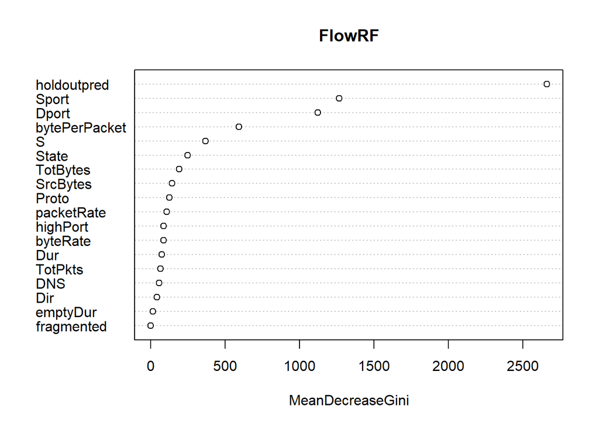

```r
varImpPlot(FlowRF,type=2)
```

Again, holdoutpred is exactly what the model predicted so it has no importance to us in this plot. We see that Sport has the largest MeanDecreaseGini, with Dport and bytePerPacket trailing behind. A bit further behind we have S, State, and TotBytes. Interestingly S has the advantage over its parent feature State. From the plot it is evident that we should try placing variable cutoffs after bytePerPacket and after TotBytes.

```r
#Cutoff 1: Sport + Dport + bytePerPacket

k <- 5
folds <- cvFolds(NROW(flowFB), K=5)
flowFB$holdoutpred <- rep(0,nrow(flowFB))
accuracy.vector <- rep(0,k)

for(i in 1:k){
  train <- flowFB[folds$subsets[folds$which != i], ] #Set the training set
  test <- flowFB[folds$subsets[folds$which == i], ] #Set the validation set

  FlowRF <- randomForest(bin~ Sport + Dport + bytePerPacket, train, ntree=120) #about sqrt(50000)/2, sqrt(50000) too large for laptop
  flow_pred <- predict(FlowRF, test)

  accuracy.vector[i] <- mean(flow_pred==test$bin)

  flowFB[folds$subsets[folds$which == i], ]$holdoutpred <- flow_pred
}

accuracy.vector
```

```
## [1] 0.9970 0.9976 0.9974 0.9978 0.9976
```

```r
CT <- CrossTable(flowFB$bin, flowFB$holdoutpred,
           prop.chisq = FALSE, prop.c = FALSE, prop.r = FALSE,
           dnn = c('actual Class', 'predicted Class'))
```

```
##
##
##    Cell Contents
## |-------------------------|
## |                       N |
## |         N / Table Total |
## |-------------------------|
##
##
## Total Observations in Table:  50000
##
##
##              | predicted Class
## actual Class |         1 |         2 | Row Total |
## -------------|-----------|-----------|-----------|
##        FALSE |     44959 |        41 |     45000 |
##              |     0.899 |     0.001 |           |
## -------------|-----------|-----------|-----------|
##         TRUE |        85 |      4915 |      5000 |
##              |     0.002 |     0.098 |           |
## -------------|-----------|-----------|-----------|
## Column Total |     45044 |      4956 |     50000 |
## -------------|-----------|-----------|-----------|
##
##
```

```r
Ten <- append(Ten, accuracy.vector[5] )
TN <- append(TN, as.numeric(CT$t['TRUE','1']))
FP <- append(FP, as.numeric(CT$t['FALSE','2']))
#AVG <- append(AVG, (50000-TN-FP)/50000)
```

Unlike with C5.0’s Cutoff 1 model, we have near-perfect accuracy for all datasets. A likely cause of this is that two of the three features are different- and probably better- for model performance.

```r
#Cutoff 2: Sport + Dport + bytePerPacket + S + State + TotBytes

k <- 5
folds <- cvFolds(NROW(flowFB), K=5)
flowFB$holdoutpred <- rep(0,nrow(flowFB))
accuracy.vector <- rep(0,k)

for(i in 1:k){
  train <- flowFB[folds$subsets[folds$which != i], ] #Set the training set
  test <- flowFB[folds$subsets[folds$which == i], ] #Set the validation set

  FlowRF <- randomForest(bin~ Sport + Dport + bytePerPacket + S + State + TotBytes, train, ntree=120) #about sqrt(50000)/2, sqrt(50000) too large for laptop

  flow_pred <- predict(FlowRF, test)

  accuracy.vector[i] <- mean(flow_pred==test$bin)

  flowFB[folds$subsets[folds$which == i], ]$holdoutpred <- flow_pred
}

accuracy.vector
```

```
## [1] 0.9979 0.9976 0.9975 0.9988 0.9983
```

```r
CT <- CrossTable(flowFB$bin, flowFB$holdoutpred,
           prop.chisq = FALSE, prop.c = FALSE, prop.r = FALSE,
           dnn = c('actual Class', 'predicted Class'))
```

```
##
##
##    Cell Contents
## |-------------------------|
## |                       N |
## |         N / Table Total |
## |-------------------------|
##
##
## Total Observations in Table:  50000
##
##
##              | predicted Class
## actual Class |         1 |         2 | Row Total |
## -------------|-----------|-----------|-----------|
##        FALSE |     44959 |        41 |     45000 |
##              |     0.899 |     0.001 |           |
## -------------|-----------|-----------|-----------|
##         TRUE |        58 |      4942 |      5000 |
##              |     0.001 |     0.099 |           |
## -------------|-----------|-----------|-----------|
## Column Total |     45017 |      4983 |     50000 |
## -------------|-----------|-----------|-----------|
##
##
```

```r
Ten <- append(Ten, accuracy.vector[5] )
TN <- append(TN, as.numeric(CT$t['TRUE','1']))
FP <- append(FP, as.numeric(CT$t['FALSE','2']))
#AVG <- append(AVG, (50000-TN-FP)/50000)
```

Again we have near-perfect accuracy among all the datasets. Also the added features make our CrossTable slightly improved for accuracy and TN’s.

# CV Boosting

Finally let’s implement boosting to see if we can get even better results.

```r
flowFC <- flowF
k <- 5
folds <- cvFolds(NROW(flowFC), K=5)
flowFC$holdoutpred <- rep(0,nrow(flowFC))
accuracy.vector <- rep(0,k)

for(i in 1:k){
  train <- flowFC[folds$subsets[folds$which != i], ] #Set the training set
  test <- flowFC[folds$subsets[folds$which == i], ] #Set the validation set
  FlowAda <- ada(bin~., data=train, iter=10) #fixed iter=10 so the model can be created quickly
  flow_pred <- predict(FlowAda, test)

  accuracy.vector[i] <- mean(flow_pred==test$bin)

  flowFC[folds$subsets[folds$which == i], ]$holdoutpred <- flow_pred
}
accuracy.vector
```

```
## [1] 0.9943 0.9952 0.9964 0.9947 0.8987
```

```r
CT <- CrossTable(flowFC$bin, flowFC$holdoutpred,
           prop.chisq = FALSE, prop.c = FALSE, prop.r = FALSE,
           dnn = c('actual Class', 'predicted Class'))
```

```
##
##
##    Cell Contents
## |-------------------------|
## |                       N |
## |         N / Table Total |
## |-------------------------|
##
##
## Total Observations in Table:  50000
##
##
##              | predicted Class
## actual Class |         1 |         2 | Row Total |
## -------------|-----------|-----------|-----------|
##        FALSE |     44937 |        63 |     45000 |
##              |     0.899 |     0.001 |           |
## -------------|-----------|-----------|-----------|
##         TRUE |      1144 |      3856 |      5000 |
##              |     0.023 |     0.077 |           |
## -------------|-----------|-----------|-----------|
## Column Total |     46081 |      3919 |     50000 |
## -------------|-----------|-----------|-----------|
##
##
```

```r
Ten <- append(Ten, accuracy.vector[5] )
TN <- append(TN, as.numeric(CT$t['TRUE','1']))
FP <- append(FP, as.numeric(CT$t['FALSE','2']))
#AVG <- append(AVG, (50000-TN-FP)/50000)
```

For a third time in a row, Dataset #10 has considerably worse accuracy which causes the number of True Negatives to be high.

# Variable Importance

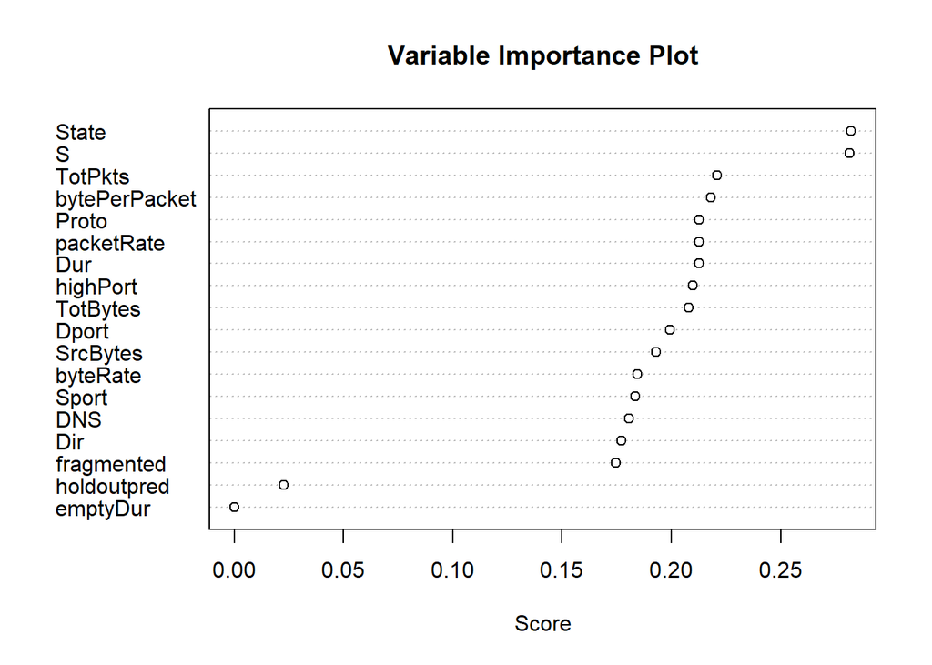

```r
varplot(FlowAda)
```

```r
#Cutoff 1: S + bytePerPacket + State
k <- 5
folds <- cvFolds(NROW(flowFC), K=5)
flowFC$holdoutpred <- rep(0,nrow(flowFC))
accuracy.vector <- rep(0,k)

for(i in 1:k){
  train <- flowFC[folds$subsets[folds$which != i], ] #Set the training set
  test <- flowFC[folds$subsets[folds$which == i], ] #Set the validation set
  FlowAda <- ada(bin~ + S + bytePerPacket + State, data=train, iter=10)
  flow_pred <- predict(FlowAda, test)

  accuracy.vector[i] <- mean(flow_pred==test$bin)

  flowFC[folds$subsets[folds$which == i], ]$holdoutpred <- flow_pred
}
accuracy.vector
```

```
## [1] 0.9710 0.9721 0.9716 0.9705 0.9712
```

```r
CT <- CrossTable(flowFC$bin, flowFC$holdoutpred,
           prop.chisq = FALSE, prop.c = FALSE, prop.r = FALSE,
           dnn = c('actual Class', 'predicted Class'))
```

```
##
##
##    Cell Contents
## |-------------------------|
## |                       N |
## |         N / Table Total |
## |-------------------------|
##
##
## Total Observations in Table:  50000
##
##
##              | predicted Class
## actual Class |         1 |         2 | Row Total |
## -------------|-----------|-----------|-----------|
##        FALSE |     44755 |       245 |     45000 |
##              |     0.895 |     0.005 |           |
## -------------|-----------|-----------|-----------|
##         TRUE |      1191 |      3809 |      5000 |
##              |     0.024 |     0.076 |           |
## -------------|-----------|-----------|-----------|
## Column Total |     45946 |      4054 |     50000 |
## -------------|-----------|-----------|-----------|
##
##
```

```r
Ten <- append(Ten, accuracy.vector[5] )
TN <- append(TN, as.numeric(CT$t['TRUE','1']))
FP <- append(FP, as.numeric(CT$t['FALSE','2']))
#AVG <- append(AVG, (50000-TN-FP)/50000)
```

The results of this model are interesting. The accuracies for all datasets in the accuracy vector are about the same at ~97%. This is higher than C5.0’s Cutoff 1 yet it is lower than RF’s Cutoff 1. Note that there are much more True Negtives than False Positives.

```r
#Cutoff 2: S + bytePerPacket + State + Dport + TotBytes
k <- 5
folds <- cvFolds(NROW(flowFC), K=5)
flowFC$holdoutpred <- rep(0,nrow(flowFC))
accuracy.vector <- rep(0,k)

for(i in 1:k){
  train <- flowFC[folds$subsets[folds$which != i], ] #Set the training set
  test <- flowFC[folds$subsets[folds$which == i], ] #Set the validation set
  FlowAda <- ada(bin~ + S + bytePerPacket + State + Dport + TotBytes, data=train, iter=10)
  flow_pred <- predict(FlowAda, test)

  accuracy.vector[i] <- mean(flow_pred==test$bin)

  flowFC[folds$subsets[folds$which == i], ]$holdoutpred <- flow_pred
}
accuracy.vector
```

```
## [1] 0.9806 0.9807 0.9809 0.9806 0.9815
```

```r
CT <- CrossTable(flowFC$bin, flowFC$holdoutpred,
           prop.chisq = FALSE, prop.c = FALSE, prop.r = FALSE,
           dnn = c('actual Class', 'predicted Class'))
```

```
##
##
##    Cell Contents
## |-------------------------|
## |                       N |
## |         N / Table Total |
## |-------------------------|
##
##
## Total Observations in Table:  50000
##
##
##              | predicted Class
## actual Class |         1 |         2 | Row Total |
## -------------|-----------|-----------|-----------|
##        FALSE |     44880 |       120 |     45000 |
##              |     0.898 |     0.002 |           |
## -------------|-----------|-----------|-----------|
##         TRUE |       837 |      4163 |      5000 |
##              |     0.017 |     0.083 |           |
## -------------|-----------|-----------|-----------|
## Column Total |     45717 |      4283 |     50000 |
## -------------|-----------|-----------|-----------|
##
##
```

```r
Ten <- append(Ten, accuracy.vector[5] )
TN <- append(TN, as.numeric(CT$t['TRUE','1']))
FP <- append(FP, as.numeric(CT$t['FALSE','2']))
#AVG <- append(AVG, (50000-TN-FP)/50000)
```

The performance of this model is consistently “slightly better” than its corresponding cutoff one. Thus adding more features was an overall improvement.

# Conclusions

Models correspond to the order in which they were introduced in the markdown. 1-3: C5.0, 4-6: RF 7-9: Ada Triple Order: No variable cutoffs, first cutoff, second cutoff

# Dataset #10 Plot

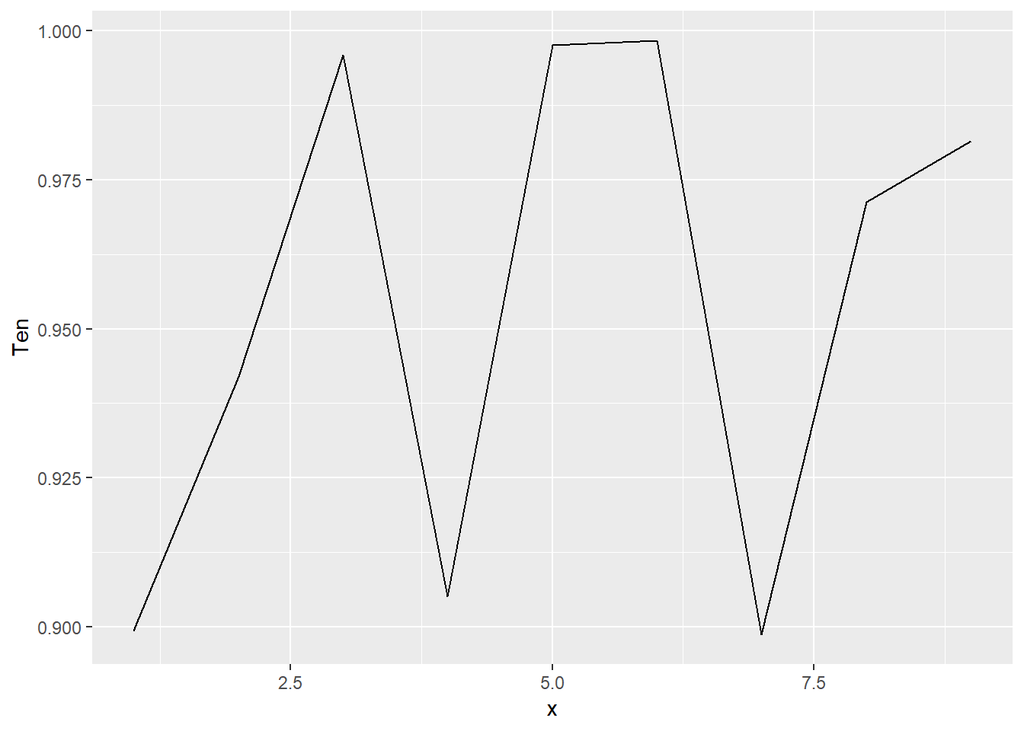

```r
ggplot(as.data.frame(Ten), aes_string(x=c(1,2,3,4,5,6,7,8,9), y=names(as.data.frame(Ten))[1]))+
  geom_line()
```

Dataset #10’s accuracy is consistently low (~90%) among models without variable cutoffs. Meanwhile it peaks (i.e is on par with the four other datasets) among the looser “second” cutoffs (Models 3,6,9). There is a likely reason why Dataset 10 is different. It is not the type of bot used- Dataset 3 also features the RBot. However, Dataset #10 is the only one of these five that features 10 bots as opposed to 1. I suppose that with more bots, comes more noise among the data. That would explain why having every feature in a model hinders the performance for Dataset #10.

# True Negative Plot

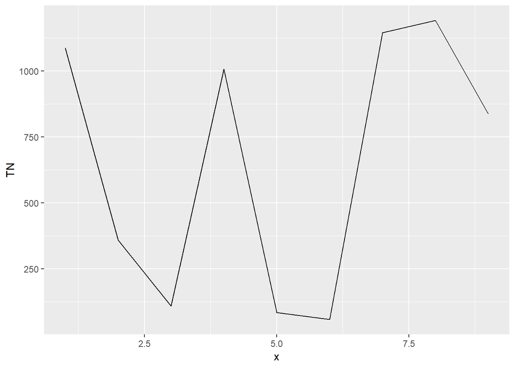

```r
ggplot(as.data.frame(TN), aes_string(x=c(1,2,3,4,5,6,7,8,9), y=names(as.data.frame(TN))[1]))+
  geom_line()
```

We see that the number of true negatives is high among models without variable cutoffs. This is likely due to Dataset #10. However, the first cutoff Boosting model (x=8) has the highest overall TN’s. What’s unique about this model is the majority of its features are State-based. So it seems that making state important would lead to many undetected bot flows.

# False Positive Plot

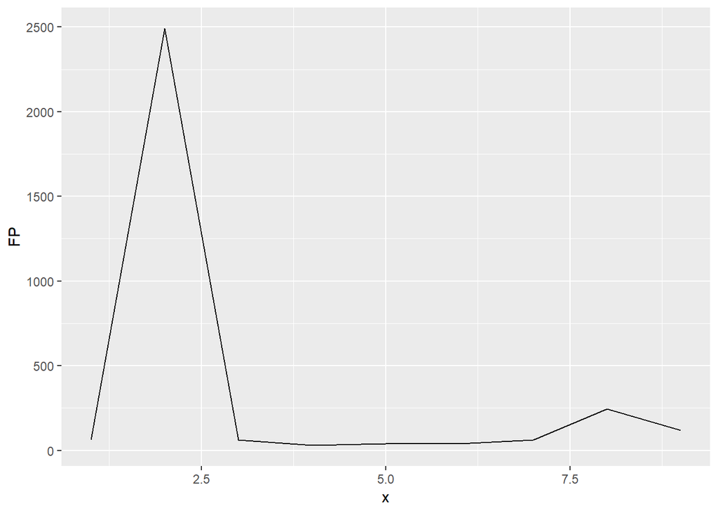

```r
ggplot(as.data.frame(FP), aes_string(x=c(1,2,3,4,5,6,7,8,9), y=names(as.data.frame(FP))[1]))+
  geom_line()
```